# Analyse bibliométrique — Trouble du Spectre de l’Autisme (TSA) et environnement

# 1 Introduction

Ce document présente une analyse bibliométrique de la littérature scientifique portant sur le **Trouble du Spectre de l’Autisme (TSA)** et ses liens avec les facteurs environnementaux. Les données sont issues de la base **Web of Science (WoS)** et analysées à l’aide du package R `bibliometrix`.

L’analyse couvre plusieurs dimensions :

- L’évolution temporelle des publications
- Les auteurs et journaux les plus productifs
- La répartition géographique des contributions
- L’impact des articles via les citations
- Les mots-clés dominants dans la littérature
- Les collaborations internationales entre pays

# 2 Configuration et chargement des packages

## 2.1 Paramètres globaux

## 2.2 Packages utilisés

Les packages suivants sont mobilisés pour l’analyse et la visualisation :

- `bibliometrix` : analyse bibliométrique (import, traitement, indicateurs)
- `tidyverse` : manipulation de données et visualisation (inclut `dplyr`, `ggplot2`, etc.)
- `viridis`, `ggthemes`, `hrbrthemes` : palettes de couleurs et thèmes graphiques
- `plotly` : graphiques interactifs
- `ggraph`, `igraph`, `tidygraph` : visualisation de réseaux

```r
library(bibliometrix)
library(tidyverse)
library(viridis)
library(plotly)
library(ggraph)
library(igraph)
library(tidygraph)
library(ggthemes)
library(hrbrthemes)
```

## 2.3 Thème graphique global

Un thème `ggplot2` minimal est défini globalement pour harmoniser l’apparence de tous les graphiques produits dans ce document.

```r
theme_set(
  theme_minimal(base_size = 14) +
    theme(
      plot.title = element_text(face = "bold", size = 18),
      plot.subtitle = element_text(size = 12),
      axis.text = element_text(color = "black"),
      panel.grid.minor = element_blank(),
      legend.position = "right"
    )
)
```

# 3 Importation et analyse des données

Les fichiers exportés depuis Web of Science (format texte brut `.txt`) sont importés via la fonction `convert2df()` de `bibliometrix`. L’analyse bibliométrique de base est ensuite réalisée avec `biblioAnalysis()`, qui calcule un ensemble d’indicateurs descriptifs (nombre de publications, auteurs, sources, citations, etc.).

```r
setwd("C:/Users/ADECHIAN/OneDrive/Documenten/tsa_project/TSA")

# Importation des données
data <- convert2df(
  file = list.files(pattern = ".txt"),
  dbsource = "wos",
  format = "plaintext"
)
```

```
##
## Converting your wos collection into a bibliographic dataframe
##
## Done!
##
##
## Generating affiliation field tag AU_UN from C1:  Done!
```

```r
# Analyse bibliométrique
results <- biblioAnalysis(data)

# Résumé
S <- summary(results, k = 10, pause = FALSE)
```

```
##
##
## MAIN INFORMATION ABOUT DATA
##
##  Timespan                              1992 : 2026
##  Sources (Journals, Books, etc)        617
##  Documents                             1574
##  Annual Growth Rate %                  7.31
##  Document Average Age                  6.32
##  Average citations per doc             35.76
##  Average citations per year per doc    4.001
##  References                            72070
##
## DOCUMENT TYPES
##  article                    1180
##  article; early access      19
##  review                     370
##  review; early access       5
##
## DOCUMENT CONTENTS
##  Keywords Plus (ID)                    3744
##  Author's Keywords (DE)                3849
##
## AUTHORS
##  Authors                               8753
##  Author Appearances                    10986
##  Authors of single-authored docs       62
##
## AUTHORS COLLABORATION
##  Single-authored docs                  67
##  Documents per Author                  0.18
##  Co-Authors per Doc                    6.98
##  International co-authorships %        26.56
##
##
## Annual Scientific Production
##
##  Year    Articles
##     1992        1
##     1998        1
```

[output cut: 109 more lines]

```
##
##
## Most Relevant Keywords
##
##         Author Keywords (DE)      Articles Keywords-Plus (ID)     Articles
## 1  AUTISM SPECTRUM DISORDER            474     CHILDREN                628
## 2  AUTISM                              385     PREVALENCE              150
## 3  AUTISM SPECTRUM DISORDERS           129     RISK                    138
## 4  ASD                                 113     SPECTRUM DISORDER       127
## 5  CHILDREN                             70     ADOLESCENTS             118
## 6  AIR POLLUTION                        61     BRAIN                   117
## 7  AUTISM SPECTRUM DISORDER (ASD)       51     SPECTRUM DISORDERS      115
## 8  NEURODEVELOPMENT                     49     EXPOSURE                106
## 9  NEURODEVELOPMENTAL DISORDERS         48     ASSOCIATION              99
## 10 ADHD                                 32     YOUNG-CHILDREN           99
```

# 4 Évolution temporelle des publications

Ce graphique représente le **nombre de publications par année** sur la thématique TSA et environnement. Il permet d’identifier les tendances de croissance ou de déclin de l’intérêt scientifique pour ce sujet au fil du temps.

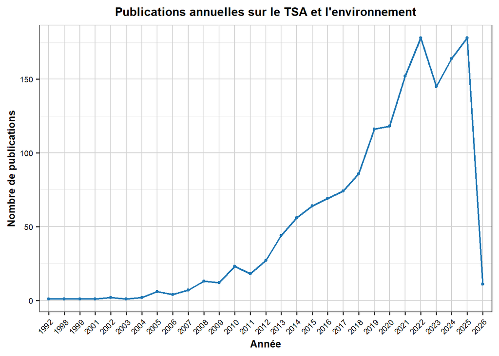

```r
# Années de publication
pubs_year <- data %>%
  count(PY) %>%
  filter(!is.na(PY))

ggplot(pubs_year, aes(x = factor(PY), y = n, group = 1)) +

  # Ligne
  geom_line(
    color = "#1f77b4",
    linewidth = 0.8
  ) +

  # Points
  geom_point(
    color = "#1f77b4",
    size = 1
  ) +

  # Titres
  labs(
    title = "Publications annuelles sur le TSA et l'environnement",
    x = "Année",
    y = "Nombre de publications"
  ) +

  # Thème
  theme_bw(base_size = 14) +

  theme(

    # Titre
    plot.title = element_text(
      hjust = 0.5,
      face = "bold",
      size = 12
    ),

    # Titres axes
    axis.title.x = element_text(
      size = 10,
      face = "bold"
    ),

    axis.title.y = element_text(
      size = 10,
      face = "bold"
    ),

    # Texte axes
    axis.text.x = element_text(
      size = 8,
      angle = 45,
      hjust = 1,
      color = "black"
    ),

    axis.text.y = element_text(
      size = 8,
      color = "black"
    ),

    # Fond blanc
    panel.background = element_rect(
      fill = "white"
    ),

    plot.background = element_rect(
      fill = "white"
    ),

    # Grille complète
    panel.grid.major = element_line(
      color = "lightgray",
      linewidth = 0.5
    ),

    panel.grid.minor = element_line(
      color = "gray90",
      linewidth = 0.25
    ),

    # Bordure noire
    panel.border = element_rect(
      color = "black",
      fill = NA,
      linewidth = 0.5
    )
  )
```

# 5 Auteurs les plus productifs

Ce graphique identifie les **20 auteurs ayant publié le plus grand nombre d’articles** dans le corpus. Ces auteurs constituent les figures centrales de la recherche sur le TSA et l’environnement.

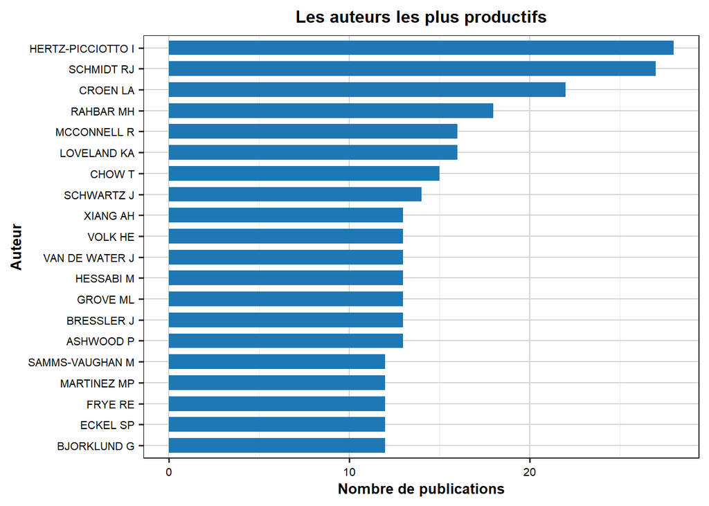

```r
# Auteurs les plus productifs
top_authors <- data.frame(
  Author = names(results$Authors),
  Freq = as.numeric(results$Authors)
)

top_authors <- top_authors %>%
  arrange(desc(Freq)) %>%
  slice_head(n = 20)

ggplot(top_authors,
       aes(x = reorder(Author, Freq),
           y = Freq)) +

  geom_bar(
    stat = "identity",
    fill = "#1f77b4",
    width = 0.7
  ) +

  coord_flip() +

  labs(
    title = "Les auteurs les plus productifs",
    x = "Auteur",
    y = "Nombre de publications"
  ) +

  theme_bw(base_size = 14) +

  theme(
    plot.title = element_text(
      hjust = 0.5,
      face = "bold",
      size = 12
    ),

    axis.title.x = element_text(
      size = 10,
      face = "bold"
    ),

    axis.title.y = element_text(
      size = 10,
      face = "bold"
    ),

    axis.text.x = element_text(
      size = 8,
      color = "black"
    ),

    axis.text.y = element_text(
      size = 8,
      color = "black"
    ),

    panel.grid.major = element_line(
      color = "lightgray",
      linewidth = 0.5
    ),

    panel.grid.minor = element_line(
      color = "gray90",
      linewidth = 0.25
    ),

    panel.border = element_rect(
      color = "black",
      fill = NA,
      linewidth = 0.5
    )
  )
```

# 6 Journaux les plus représentés

Ce graphique présente les **20 revues scientifiques** ayant publié le plus d’articles du corpus. Il renseigne sur les supports de diffusion privilégiés par les chercheurs travaillant sur le TSA et l’environnement.

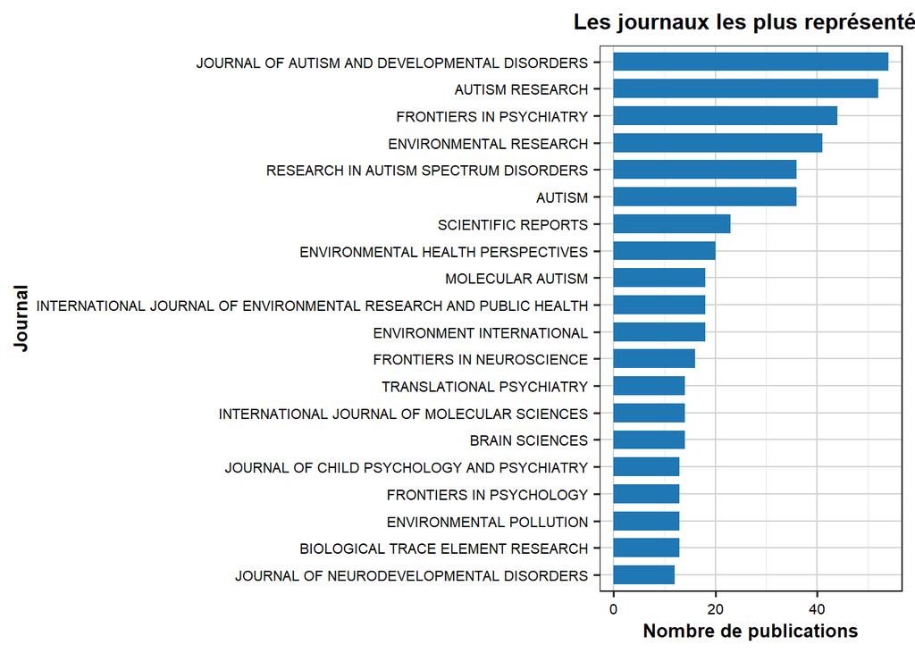

```r
# Journaux les plus représentés
top_sources <- data.frame(
  Journal = names(results$Sources),
  Freq = as.numeric(results$Sources)
)

top_sources <- top_sources %>%
  arrange(desc(Freq)) %>%
  slice_head(n = 20)

ggplot(top_sources,
       aes(x = reorder(Journal, Freq),
           y = Freq)) +

  geom_bar(
    stat = "identity",
    fill = "#1f77b4",
    width = 0.7
  ) +

  coord_flip() +

  labs(
    title = "Les journaux les plus représentés",
    x = "Journal",
    y = "Nombre de publications"
  ) +

  theme_bw(base_size = 14) +

  theme(
    plot.title = element_text(
      hjust = 0.5,
      face = "bold",
      size = 12
    ),

    axis.title.x = element_text(
      size = 10,
      face = "bold"
    ),

    axis.title.y = element_text(
      size = 10,
      face = "bold"
    ),

    axis.text.x = element_text(
      size = 8,
      color = "black"
    ),

    axis.text.y = element_text(
      size = 8,
      color = "black"
    ),

    panel.grid.major = element_line(
      color = "lightgray",
      linewidth = 0.5
    ),

    panel.grid.minor = element_line(
      color = "gray90",
      linewidth = 0.25
    ),

    panel.border = element_rect(
      color = "black",
      fill = NA,
      linewidth = 0.5
    )
  )
```

# 7 Répartition géographique des publications

## 7.1 Pays les plus productifs

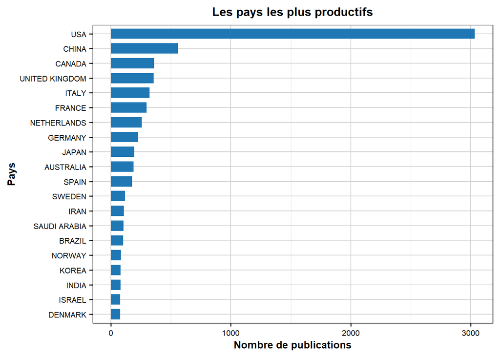

```r
# Extraction des pays
top_countries <- metaTagExtraction(
  data,
  Field = "AU_CO",
  sep = ";"
)

# Séparer les pays correctement
country_freq <- top_countries %>%

  select(AU_CO) %>%

  separate_rows(AU_CO, sep = ";") %>%

  mutate(
    AU_CO = str_trim(AU_CO)
  ) %>%

  filter(AU_CO != "") %>%

  count(AU_CO, sort = TRUE) %>%

  slice_head(n = 20)

# Graphique
ggplot(country_freq,
       aes(x = reorder(AU_CO, n),
           y = n)) +

  geom_bar(
    stat = "identity",
    fill = "#1f77b4",
    width = 0.7
  ) +

  coord_flip() +

  labs(
    title = "Les pays les plus productifs",
    x = "Pays",
    y = "Nombre de publications"
  ) +

  theme_bw(base_size = 14) +

  theme(

    plot.title = element_text(
      hjust = 0.5,
      face = "bold",
      size = 12
    ),

    axis.title.x = element_text(
      size = 10,
      face = "bold"
    ),

    axis.title.y = element_text(
      size = 10,
      face = "bold"
    ),

    axis.text.x = element_text(
      size = 8,
      color = "black"
    ),

    axis.text.y = element_text(
      size = 8,
      color = "black"
    ),

    panel.grid.major = element_line(
      color = "lightgray",
      linewidth = 0.5
    ),

    panel.grid.minor = element_line(
      color = "gray90",
      linewidth = 0.25
    ),

    panel.border = element_rect(
      color = "black",
      fill = NA,
      linewidth = 0.5
    )
  )
```

# 8 Analyse des citations

## 8.1 Fréquence moyenne de citations par article et par an

Pour chaque article, le nombre de citations annualisé est calculé en divisant le total de citations (`TC`) par l’âge de l’article (depuis sa publication jusqu’en 2026). La moyenne de cet indicateur est ensuite agrégée par année de publication.

Ce graphique permet d’évaluer l’**impact relatif** des articles produits chaque année, en corrigeant le biais lié à l’ancienneté des publications.

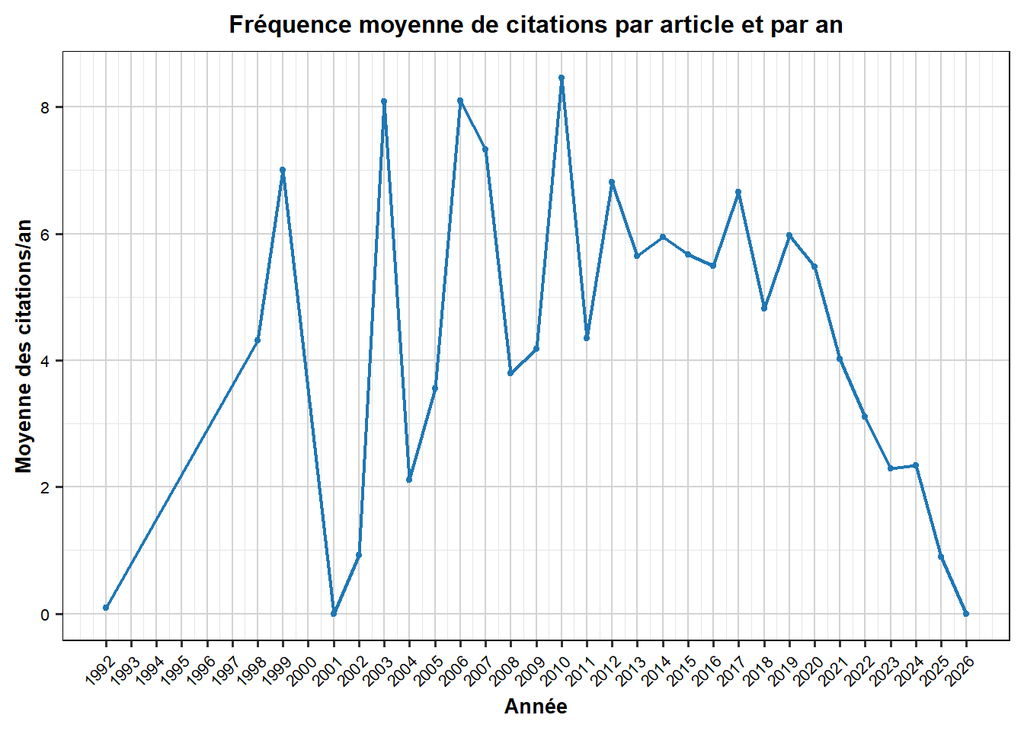

```r
# FREQUENCE MOYENNE DE CITATIONS PAR ARTICLE ET PAR AN

current_year <- 2026

# Calcul citations/an pour chaque article
data$citations_per_year <- data$TC / (current_year - data$PY + 1)

# Moyenne par année
mean_citations <- data %>%
  group_by(PY) %>%
  summarise(
    mean_citations_per_year = mean(
      citations_per_year,
      na.rm = TRUE
    )
  )

# Graphique
ggplot(
  mean_citations,
  aes(
    x = PY,
    y = mean_citations_per_year
  )
) +

  geom_line(
    color = "#1f77b4",
    linewidth = 0.8
  ) +

  geom_point(
    color = "#1f77b4",
    size = 1
  ) +

  labs(
    title = "Fréquence moyenne de citations par article et par an",
    x = "Année",
    y = "Moyenne des citations/an"
  ) +

  scale_x_continuous(
    breaks = seq(
      min(mean_citations$PY),
      max(mean_citations$PY),
      by = 1
    )
  ) +

  theme_bw(base_size = 14) +

  theme(

    # Titre
    plot.title = element_text(
      hjust = 0.5,
      face = "bold",
      size = 12
    ),

    # Titres axes
    axis.title.x = element_text(
      size = 10,
      face = "bold"
    ),

    axis.title.y = element_text(
      size = 10,
      face = "bold"
    ),

    # Texte axes
    axis.text.x = element_text(
      size = 8,
      angle = 45,
      hjust = 1,
      color = "black"
    ),

    axis.text.y = element_text(
      size = 8,
      color = "black"
    ),

    # Fond blanc
    panel.background = element_rect(
      fill = "white"
    ),

    plot.background = element_rect(
      fill = "white"
    ),

    # Grille
    panel.grid.major = element_line(
      color = "lightgray",
      linewidth = 0.5
    ),

    panel.grid.minor = element_line(
      color = "gray90",
      linewidth = 0.25
    ),

    # Bordure
    panel.border = element_rect(
      color = "black",
      fill = NA,
      linewidth = 0.5
    )
  )
```

## 8.2 Nombre moyen total de citations par an

Ce graphique complète le précédent en affichant la **moyenne brute du total de citations** (`TC`) reçues par les articles d’une même année de publication. Contrairement à l’indicateur annualisé, il reflète l’accumulation absolue de citations au fil du temps.

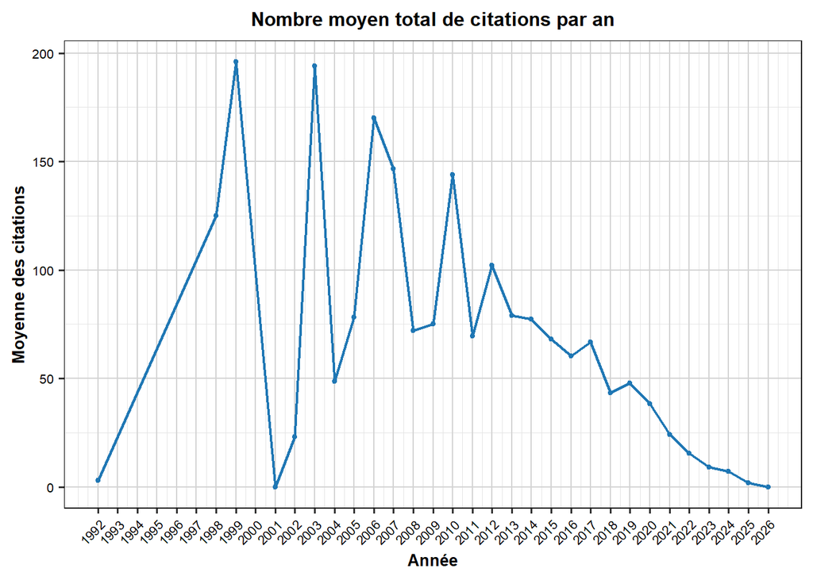

```r
# NOMBRE MOYEN TOTAL DE CITATIONS PAR AN

# Moyenne des citations totales par année
mean_total_citations <- data %>%
  group_by(PY) %>%
  summarise(
    mean_total_TC = mean(
      TC,
      na.rm = TRUE
    )
  )

# Graphique
ggplot(
  mean_total_citations,
  aes(
    x = PY,
    y = mean_total_TC
  )
) +

  geom_line(
    color = "#1f77b4",
    linewidth = 0.8
  ) +

  geom_point(
    color = "#1f77b4",
    size = 1
  ) +

  labs(
    title = "Nombre moyen total de citations par an",
    x = "Année",
    y = "Moyenne des citations"
  ) +

  scale_x_continuous(
    breaks = seq(
      min(mean_total_citations$PY),
      max(mean_total_citations$PY),
      by = 1
    )
  ) +

  theme_bw(base_size = 14) +

  theme(

    # Titre
    plot.title = element_text(
      hjust = 0.5,
      face = "bold",
      size = 12
    ),

    # Titres axes
    axis.title.x = element_text(
      size = 10,
      face = "bold"
    ),

    axis.title.y = element_text(
      size = 10,
      face = "bold"
    ),

    # Texte axes
    axis.text.x = element_text(
      size = 8,
      angle = 45,
      hjust = 1,
      color = "black"
    ),

    axis.text.y = element_text(
      size = 8,
      color = "black"
    ),

    # Fond blanc
    panel.background = element_rect(
      fill = "white"
    ),

    plot.background = element_rect(
      fill = "white"
    ),

    # Grille
    panel.grid.major = element_line(
      color = "lightgray",
      linewidth = 0.5
    ),

    panel.grid.minor = element_line(
      color = "gray90",
      linewidth = 0.25
    ),

    # Bordure
    panel.border = element_rect(
      color = "black",
      fill = NA,
      linewidth = 0.5
    )
  )
```

# 9 Mots-clés les plus fréquents

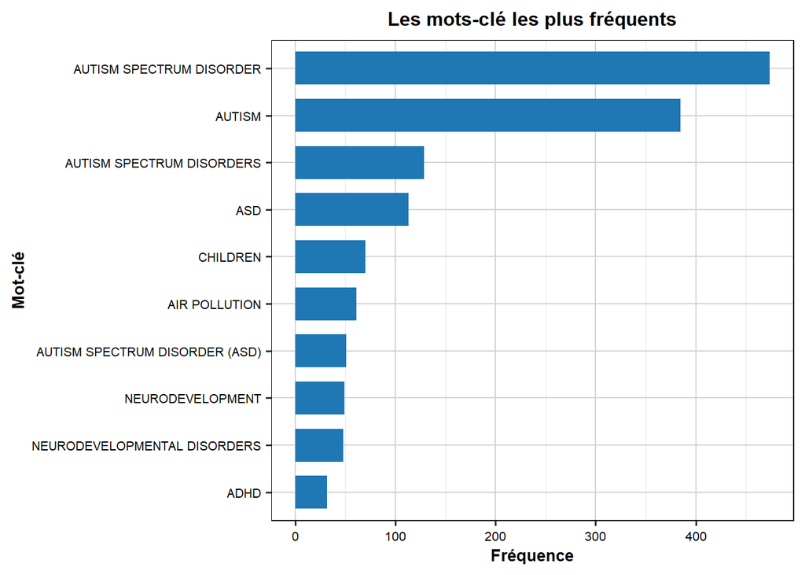

```r
# TOP 10 DES MOTS-CLES

# Extraction des mots-clés
keywords <- data$DE %>%

  na.omit() %>%

  str_split(";") %>%

  unlist() %>%

  str_trim()

# Fréquences
keywords_freq <- as.data.frame(
  sort(
    table(keywords),
    decreasing = TRUE
  )
)

# Renommage colonnes
colnames(keywords_freq) <- c(
  "Keyword",
  "Freq"
)

# Top 10
keywords_freq <- keywords_freq %>%

  slice_head(n = 10)

# Graphique
ggplot(
  keywords_freq,
  aes(
    x = reorder(Keyword, Freq),
    y = Freq
  )
) +

  geom_bar(
    stat = "identity",
    fill = "#1f77b4",
    width = 0.7
  ) +

  coord_flip() +

  labs(
    title = "Les mots-clé les plus fréquents",
    x = "Mot-clé",
    y = "Fréquence"
  ) +

  theme_bw(base_size = 14) +

  theme(

    # Titre
    plot.title = element_text(
      hjust = 0.5,
      face = "bold",
      size = 12
    ),

    # Titres axes
    axis.title.x = element_text(
      size = 10,
      face = "bold"
    ),

    axis.title.y = element_text(
      size = 10,
      face = "bold"
    ),

    # Texte axes
    axis.text.x = element_text(
      size = 8,
      color = "black"
    ),

    axis.text.y = element_text(
      size = 8,
      color = "black"
    ),

    # Fond blanc
    panel.background = element_rect(
      fill = "white"
    ),

    plot.background = element_rect(
      fill = "white"
    ),

    # Grille
    panel.grid.major = element_line(
      color = "lightgray",
      linewidth = 0.5
    ),

    panel.grid.minor = element_line(
      color = "gray90",
      linewidth = 0.25
    ),

    # Bordure
    panel.border = element_rect(
      color = "black",
      fill = NA,
      linewidth = 0.5
    )
  )
```

# 10 Collaborations internationales

Ce dernier volet analyse les **collaborations entre pays**. Pour chaque article multi-pays, toutes les paires de pays co-auteurs sont générées via la fonction `combn()`. Le décompte final indique combien de fois chaque pays apparaît dans une paire de collaboration internationale, ce qui reflète son degré d’ouverture et d’intégration dans les réseaux de recherche mondiaux.

Seuls les **10 pays les plus collaboratifs** sont représentés dans le graphique.

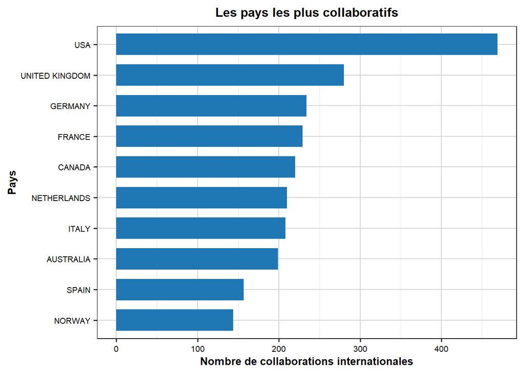

```r
# PAYS AYANT LE PLUS COLLABORE AVEC D'AUTRES PAYS

# Extraction des pays
country_data <- metaTagExtraction(
  data,
  Field = "AU_CO",
  sep = ";"
)

# Liste des pays par article
articles_countries <- country_data %>%

  select(AU_CO) %>%

  mutate(
    AU_CO = str_split(AU_CO, ";")
  ) %>%

  mutate(
    AU_CO = map(
      AU_CO,
      ~ unique(str_trim(.x))
    )
  )

# Création des paires de collaborations
collab_list <- list()

for(i in 1:nrow(articles_countries)) {

  countries <- articles_countries$AU_CO[[i]]

  # Garder uniquement collaborations internationales
  if(length(countries) > 1) {

    pairs <- combn(
      countries,
      2,
      simplify = FALSE
    )

    collab_list <- append(
      collab_list,
      pairs
    )
  }
}

# Transformation en dataframe
collab_df <- do.call(
  rbind,
  lapply(
    collab_list,
    function(x) {
      data.frame(
        country1 = x[1],
        country2 = x[2]
      )
    }
  )
)

# Comptage collaborations par pays
country_collab <- collab_df %>%

  pivot_longer(
    cols = c(country1, country2),
    values_to = "Country"
  ) %>%

  count(
    Country,
    sort = TRUE
  ) %>%

  slice_head(n = 10)

# Graphique
ggplot(
  country_collab,
  aes(
    x = reorder(Country, n),
    y = n
  )
) +

  geom_bar(
    stat = "identity",
    fill = "#1f77b4",
    width = 0.7
  ) +

  coord_flip() +

  labs(
    title = "Les pays les plus collaboratifs",
    x = "Pays",
    y = "Nombre de collaborations internationales"
  ) +

  theme_bw(base_size = 14) +

  theme(

    # Titre
    plot.title = element_text(
      hjust = 0.5,
      face = "bold",
      size = 12
    ),

    # Titres axes
    axis.title.x = element_text(
      size = 10,
      face = "bold"
    ),

    axis.title.y = element_text(
      size = 10,
      face = "bold"
    ),

    # Texte axes
    axis.text.x = element_text(
      size = 8,
      color = "black"
    ),

    axis.text.y = element_text(
      size = 8,
      color = "black"
    ),

    # Fond blanc
    panel.background = element_rect(
      fill = "white"
    ),

    plot.background = element_rect(
      fill = "white"
    ),

    # Grille
    panel.grid.major = element_line(
      color = "lightgray",
      linewidth = 0.5
    ),

    panel.grid.minor = element_line(
      color = "gray90",
      linewidth = 0.25
    ),

    # Bordure
    panel.border = element_rect(
      color = "black",
      fill = NA,
      linewidth = 0.5
    )
  )
```

*Analyse réalisée avec R et le package `bibliometrix`. Données source : Web of Science (WoS), format texte brut.*